# Supervised Learning - Foundations Project: ReCell

## Problem Statement

### Business Context

Buying and selling used phones and tablets used to be something that happened on a handful of online marketplace sites. But the used and refurbished device market has grown considerably over the past decade, and a new IDC (International Data Corporation) forecast predicts that the used phone market would be worth \$52.7bn by 2023 with a compound annual growth rate (CAGR) of 13.6% from 2018 to 2023. This growth can be attributed to an uptick in demand for used phones and tablets that offer considerable savings compared with new models.

Refurbished and used devices continue to provide cost-effective alternatives to both consumers and businesses that are looking to save money when purchasing one. There are plenty of other benefits associated with the used device market. Used and refurbished devices can be sold with warranties and can also be insured with proof of purchase. Third-party vendors/platforms, such as Verizon, Amazon, etc., provide attractive offers to customers for refurbished devices. Maximizing the longevity of devices through second-hand trade also reduces their environmental impact and helps in recycling and reducing waste. The impact of the COVID-19 outbreak may further boost this segment as consumers cut back on discretionary spending and buy phones and tablets only for immediate needs.

### Objective

The rising potential of this comparatively under-the-radar market fuels the need for an ML-based solution to develop a dynamic pricing strategy for used and refurbished devices. ReCell, a startup aiming to tap the potential in this market, has hired you as a data scientist. They want you to analyze the data provided and build a linear regression model to predict the price of a used phone/tablet and identify factors that significantly influence it.

### Data Description

The data contains the different attributes of used/refurbished phones and tablets. The data was collected in the year 2021. The detailed data dictionary is given below.

- brand_name: Name of manufacturing brand
- os: OS on which the device runs
- screen_size: Size of the screen in cm
- 4g: Whether 4G is available or not
- 5g: Whether 5G is available or not
- main_camera_mp: Resolution of the rear camera in megapixels
- selfie_camera_mp: Resolution of the front camera in megapixels
- int_memory: Amount of internal memory (ROM) in GB
- ram: Amount of RAM in GB
- battery: Energy capacity of the device battery in mAh
- weight: Weight of the device in grams
- release_year: Year when the device model was released
- days_used: Number of days the used/refurbished device has been used
- normalized_new_price: Normalized price of a new device of the same model in euros
- normalized_used_price: Normalized price of the used/refurbished device in euros

## Importing necessary libraries

```python
# this will help in making the Python code more structured automatically (good coding practice)
%load_ext nb_black

# Libraries to help with reading and manipulating data
import numpy as np
import pandas as pd

# Libraries to help with data visualization
import matplotlib.pyplot as plt
import seaborn as sns

sns.set()

# split the data into train and test
from sklearn.model_selection import train_test_split

# to build linear regression_model
from sklearn.linear_model import LinearRegression

# to check model performance
from sklearn.metrics import mean_absolute_error, mean_squared_error, r2_score

# to build linear regression_model using statsmodels
import statsmodels.api as sm

# to compute VIF
from statsmodels.stats.outliers_influence import variance_inflation_factor
```

## Loading the dataset

```python
# loading data
data = pd.read_csv("C:\\Users\\USER\\Downloads\\used_device_data.csv")
```

## Data Overview

- Observations
- Sanity checks

```python
data.head()  # view first 5 rows of the dataset
```

|  | brand_name | os | screen_size | 4g | 5g | main_camera_mp | selfie_camera_mp | int_memory | ram | battery | weight | release_year | days_used | normalized_used_price | normalized_new_price |
| --- | --- | --- | --- | --- | --- | --- | --- | --- | --- | --- | --- | --- | --- | --- | --- |
| 0 | Honor | Android | 14.50 | yes | no | 13.0 | 5.0 | 64.0 | 3.0 | 3020.0 | 146.0 | 2020 | 127 | 4.307572 | 4.715100 |
| 1 | Honor | Android | 17.30 | yes | yes | 13.0 | 16.0 | 128.0 | 8.0 | 4300.0 | 213.0 | 2020 | 325 | 5.162097 | 5.519018 |
| 2 | Honor | Android | 16.69 | yes | yes | 13.0 | 8.0 | 128.0 | 8.0 | 4200.0 | 213.0 | 2020 | 162 | 5.111084 | 5.884631 |
| 3 | Honor | Android | 25.50 | yes | yes | 13.0 | 8.0 | 64.0 | 6.0 | 7250.0 | 480.0 | 2020 | 345 | 5.135387 | 5.630961 |
| 4 | Honor | Android | 15.32 | yes | no | 13.0 | 8.0 | 64.0 | 3.0 | 5000.0 | 185.0 | 2020 | 293 | 4.389995 | 4.947837 |

```python
data.shape  # number of rows and columns of the dataset
```

```
(3454, 15)
```

- There are 3454 rows and 15 columns shown in the dataset.

```python
data.info()  # Check datatypes for the columns in the dataset
```

```
<class 'pandas.core.frame.DataFrame'>
RangeIndex: 3454 entries, 0 to 3453
Data columns (total 15 columns):
 #   Column                 Non-Null Count  Dtype
---  ------                 --------------  -----
 0   brand_name             3454 non-null   object
 1   os                     3454 non-null   object
 2   screen_size            3454 non-null   float64
 3   4g                     3454 non-null   object
 4   5g                     3454 non-null   object
 5   main_camera_mp         3275 non-null   float64
 6   selfie_camera_mp       3452 non-null   float64
 7   int_memory             3450 non-null   float64
 8   ram                    3450 non-null   float64
 9   battery                3448 non-null   float64
 10  weight                 3447 non-null   float64
 11  release_year           3454 non-null   int64
 12  days_used              3454 non-null   int64
 13  normalized_used_price  3454 non-null   float64
 14  normalized_new_price   3454 non-null   float64
dtypes: float64(9), int64(2), object(4)
memory usage: 404.9+ KB
```

- There are four (4) columns of object type : brand_name, os, 4g and 5g. These also represent categorical type of data.
- Two (2) columns of integer(int64) type: release year and days used. 'release year' can be classified as categorical while 'days_used' is numerical in nature.
- Nine (9) of the columns are of float datatype: screen_size, main_camera_mp, selfie_camera_mp, int_memory, ram, battery, weight, normalized_used_price, normalized_new_price. These are numerical types of data.

```python
data.describe(include="all").T  # check for statistical summary of the dataset.
```

|  | count | unique | top | freq | mean | std | min | 25% | 50% | 75% | max |
| --- | --- | --- | --- | --- | --- | --- | --- | --- | --- | --- | --- |
| brand_name | 3454 | 34 | Others | 502 | NaN | NaN | NaN | NaN | NaN | NaN | NaN |
| os | 3454 | 4 | Android | 3214 | NaN | NaN | NaN | NaN | NaN | NaN | NaN |
| screen_size | 3454.0 | NaN | NaN | NaN | 13.713115 | 3.80528 | 5.08 | 12.7 | 12.83 | 15.34 | 30.71 |
| 4g | 3454 | 2 | yes | 2335 | NaN | NaN | NaN | NaN | NaN | NaN | NaN |
| 5g | 3454 | 2 | no | 3302 | NaN | NaN | NaN | NaN | NaN | NaN | NaN |
| main_camera_mp | 3275.0 | NaN | NaN | NaN | 9.460208 | 4.815461 | 0.08 | 5.0 | 8.0 | 13.0 | 48.0 |
| selfie_camera_mp | 3452.0 | NaN | NaN | NaN | 6.554229 | 6.970372 | 0.0 | 2.0 | 5.0 | 8.0 | 32.0 |
| int_memory | 3450.0 | NaN | NaN | NaN | 54.573099 | 84.972371 | 0.01 | 16.0 | 32.0 | 64.0 | 1024.0 |
| ram | 3450.0 | NaN | NaN | NaN | 4.036122 | 1.365105 | 0.02 | 4.0 | 4.0 | 4.0 | 12.0 |
| battery | 3448.0 | NaN | NaN | NaN | 3133.402697 | 1299.682844 | 500.0 | 2100.0 | 3000.0 | 4000.0 | 9720.0 |
| weight | 3447.0 | NaN | NaN | NaN | 182.751871 | 88.413228 | 69.0 | 142.0 | 160.0 | 185.0 | 855.0 |
| release_year | 3454.0 | NaN | NaN | NaN | 2015.965258 | 2.298455 | 2013.0 | 2014.0 | 2015.5 | 2018.0 | 2020.0 |
| days_used | 3454.0 | NaN | NaN | NaN | 674.869716 | 248.580166 | 91.0 | 533.5 | 690.5 | 868.75 | 1094.0 |
| normalized_used_price | 3454.0 | NaN | NaN | NaN | 4.364712 | 0.588914 | 1.536867 | 4.033931 | 4.405133 | 4.7557 | 6.619433 |
| normalized_new_price | 3454.0 | NaN | NaN | NaN | 5.233107 | 0.683637 | 2.901422 | 4.790342 | 5.245892 | 5.673718 | 7.847841 |

- There are 34 unique brands represented in the dataset. The 'others' column has the highest count of these.
- Four (4) os types are shown in the dataset with 'Android' showing the highest count. 3214 phones captured in the dataset use the android operating system.
- The average screen size of the phones is approximately 13.7 cm; the minimum and maximum are 5.08 cm and 30.71 cm respectively. An average number of phones have a screen size of 12.83 cm. 25% of the phones have screen size of at least 12.7 cm while 75% have at most 15.34 cm.
- More phones (2335) are configured for 4g technology than for the 5g (152).
- The average resolution for the main camera of the phones in the dataset (9.5 megapixels) is relatively higher than the selfie camera (6.6 megapixels). The maximum resolution recorded for both sets are 48.0 megapixels and 32.0 megapixels respectively. An average number of phones have a resolution of 8.0 megapixels for the main camera and 5.0 for the selfie camera. 25% of phones have resolutions of at least 5.0 megapixels for the main camera and 2.0 megapixels for the selfie camera. 75% of these phones have at most 13.0 megapixels and 8.0 megapixels for the main and selfie cameras respectively.
- The average memory size of the phones is about 54.6 GB while the biggest memory size recorded is 1024 GB. A mean number of phones have about 32 GB of memory. 25% of the phones have at least 16 GB ROM while 75% have at most 64 GB ROM.
- The mean ram size of the phones is about 4 GB while the biggest ram size recorded is 12 GB. An average number of phones have ram size of about 4 GB. 25% of the phones have at least 4 GB ram size while 75% also have at most 4 GB ram size.
- The average battery capacity of the phones is approximately 3133.4 mAh; the minimum and maximum are 500 mAh and 9720 mAh respectively. An average number of phones have a capacity of 3000 mAh. 25% of the phones have capacity of at least 2100 mAh while 75% have at most 4000 mAh.
- The mean weight of the phones is about 182.8 g while the highest weight recorded is 855 g. A mean number of phones have weight of about 160 g. 25% of the phones are at least 142 g while 75% also are at most 185 g.
- The oldest phone in the dataset was manufactured in 2013 and the earliest in 2020.
- The most used phone was used for 1094 days whilst the phone that was least used was used for 91 days. The mean number of 'usage days' is approximately 675 days. 50% of phones were used for 690.5 days whilst 25% were used for at least 533.5 days. 75% were used for at most 869 days.
- The mean normalized price of a used device is about 4.4 euros while the highest normalized price of a used device recorded is about 6.6 euros while the mean normalized price of a new device is about 5.2 euros and the highest 7.8 euros.

```python
data.duplicated().sum()  # check for duplicate values
```

```
0
```

- There are no duplicate values in the dataset.

```python
data.isna().sum()  # missing value check
```

```
brand_name                 0
os                         0
screen_size                0
4g                         0
5g                         0
main_camera_mp           179
selfie_camera_mp           2
int_memory                 4
ram                        4
battery                    6
weight                     7
release_year               0
days_used                  0
normalized_used_price      0
normalized_new_price       0
dtype: int64
```

- Six (6) columns have missing values. These are main_camera_mp, selfie_camera_mp, int_memory, ram, battery and weight.

```python
# create a copy of the data so that original data remains unchanged
df = data.copy()
```

## Exploratory Data Analysis (EDA)

- EDA is an important part of any project involving data.
- It is important to investigate and understand the data better before building a model with it.
- A few questions have been mentioned below which will help you approach the analysis in the right manner and generate insights from the data.
- A thorough analysis of the data, in addition to the questions mentioned below, should be done.

**Questions**:

1. What does the distribution of normalized used device prices look like?
2. What percentage of the used device market is dominated by Android devices?
3. The amount of RAM is important for the smooth functioning of a device. How does the amount of RAM vary with the brand?
4. A large battery often increases a device's weight, making it feel uncomfortable in the hands. How does the weight vary for phones and tablets offering large batteries (more than 4500 mAh)?
5. Bigger screens are desirable for entertainment purposes as they offer a better viewing experience. How many phones and tablets are available across different brands with a screen size larger than 6 inches?
6. A lot of devices nowadays offer great selfie cameras, allowing us to capture our favorite moments with loved ones. What is the distribution of devices offering greater than 8MP selfie cameras across brands?
7. Which attributes are highly correlated with the normalized price of a used device?

#### DISTRIBUTION OF NORMALIZED USED PRICES

```python
# function to plot a boxplot and a histogram along the same scale.


def histogram_boxplot(data, feature, figsize=(15, 10), kde=False, bins=None):
    """
    Boxplot and histogram combined

    data: dataframe
    feature: dataframe column
    figsize: size of figure (default (15,10))
    kde: whether to show the density curve (default False)
    bins: number of bins for histogram (default None)
    """
    f2, (ax_box2, ax_hist2) = plt.subplots(
        nrows=2,  # Number of rows of the subplot grid= 2
        sharex=True,  # x-axis will be shared among all subplots
        gridspec_kw={"height_ratios": (0.25, 0.75)},
        figsize=figsize,
    )  # creating the 2 subplots
    sns.boxplot(
        data=data, x=feature, ax=ax_box2, showmeans=True, color="violet"
    )  # boxplot will be created and a triangle will indicate the mean value of the column
    sns.histplot(
        data=data, x=feature, kde=kde, ax=ax_hist2, bins=bins
    ) if bins else sns.histplot(
        data=data, x=feature, kde=kde, ax=ax_hist2
    )  # For histogram
    ax_hist2.axvline(
        data[feature].mean(), color="green", linestyle="--"
    )  # Add mean to the histogram
    ax_hist2.axvline(
        data[feature].median(), color="black", linestyle="-"
    )  # Add median to the histogram
```

```python
# function to create labeled barplots


def labeled_barplot(data, feature, perc=False, n=None):
    """
    Barplot with percentage at the top

    data: dataframe
    feature: dataframe column
    perc: whether to display percentages instead of count (default is False)
    n: displays the top n category levels (default is None, i.e., display all levels)
    """

    total = len(data[feature])  # length of the column
    count = data[feature].nunique()
    if n is None:
        plt.figure(figsize=(count + 2, 6))
    else:
        plt.figure(figsize=(n + 2, 6))

    plt.xticks(rotation=90, fontsize=15)
    ax = sns.countplot(
        data=data,
        x=feature,
        palette="Paired",
        order=data[feature].value_counts().index[:n],
    )

    for p in ax.patches:
        if perc == True:
            label = "{:.1f}%".format(
                100 * p.get_height() / total
            )  # percentage of each class of the category
        else:
            label = p.get_height()  # count of each level of the category

        x = p.get_x() + p.get_width() / 2  # width of the plot
        y = p.get_height()  # height of the plot

        ax.annotate(
            label,
            (x, y),
            ha="center",
            va="center",
            size=12,
            xytext=(0, 5),
            textcoords="offset points",
        )  # annotate the percentage

    plt.show()  # show the plot
```

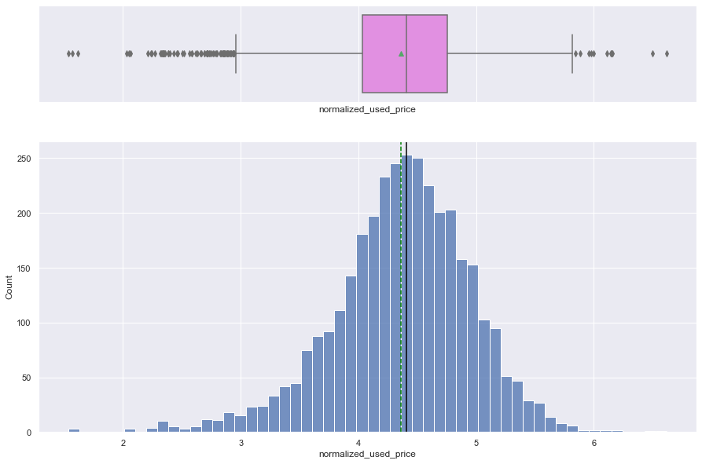

```python
histogram_boxplot(
    df, "normalized_used_price"
)  # show histogram and boxplot of normalized used price
```

- The distribution of this column is slightly left skewed as 50% of the used prices are slightly greater than the average.
- A higher concentration of outliers to the left of the 'lower whisker' indicates a lot of 'cheap used phones' on the market compared to the exorbitant ones.

#### DISTRIBUTION NORMALIZED NEW PRICE

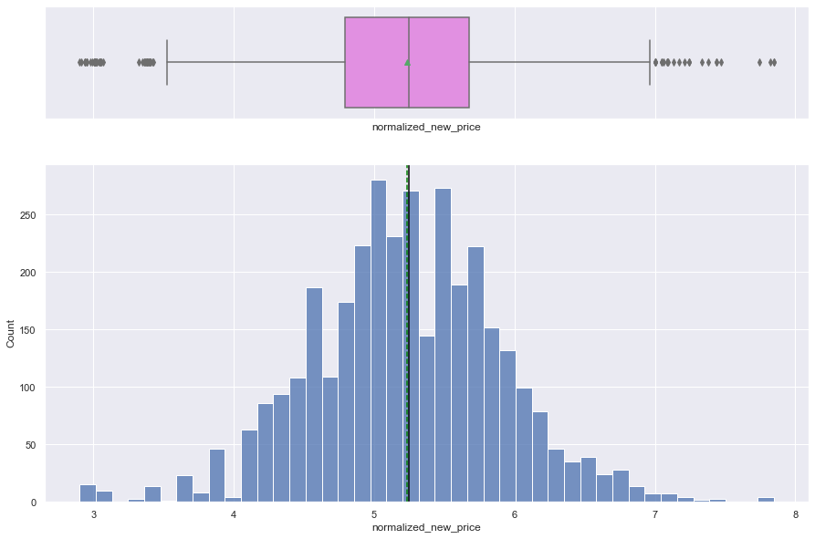

```python
histogram_boxplot(
    df, "normalized_new_price"
)  # show histogram and boxplot of normalized new price
```

- The distribution is quite normal as the median and mean price are fairly equal.

#### DISTRIBUTION OF SCREEN SIZE

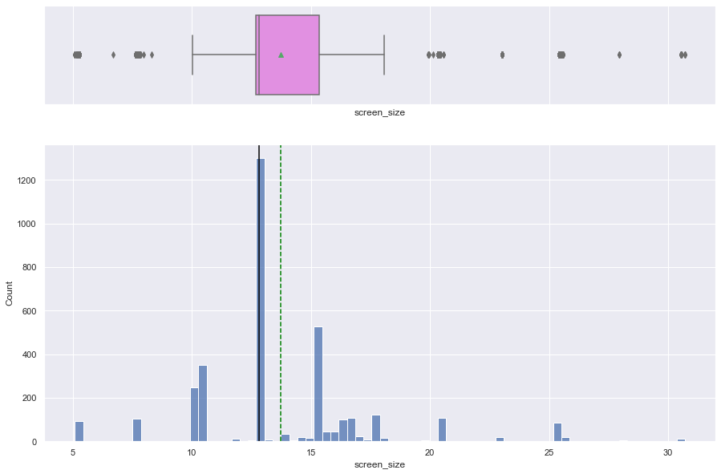

```python
histogram_boxplot(df, "screen_size")  # show histogram and boxplot of screen size
```

- The distribution is significantly right skewed as 50% of phones on the market are less than the average screen size.
- There are a fair number of phones with screen sizes at least two times greater than the average.

#### DISTRIBUTION MAIN CAMERA MP

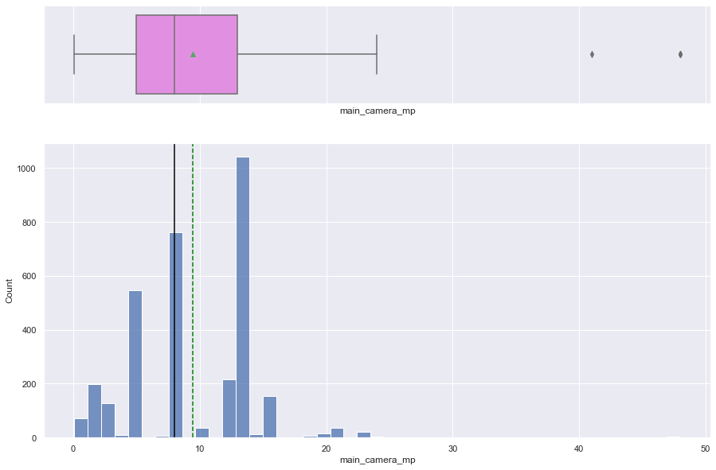

```python
histogram_boxplot(
    df, "main_camera_mp"
)  # show histogram and boxplot of main camera resolution
```

#### DISTRIBUTION SELFIE CAMERA MP

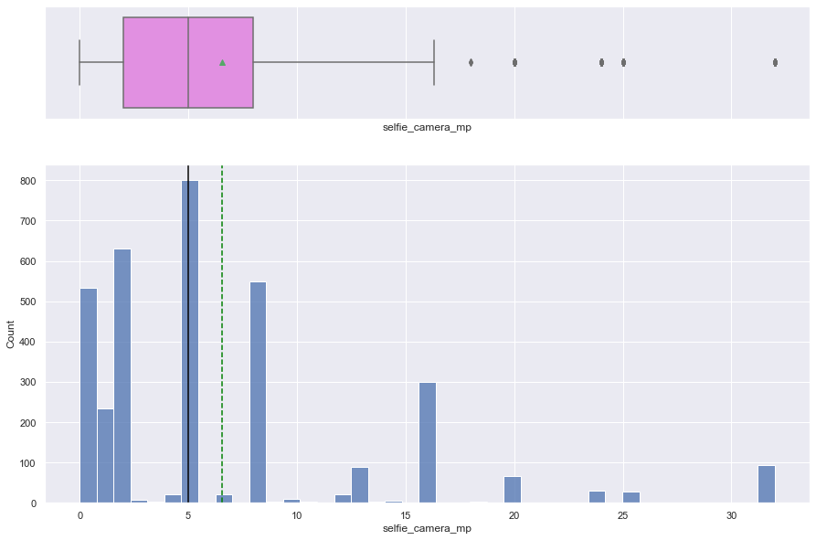

```python
histogram_boxplot(
    df, "selfie_camera_mp"
)  # show histogram and boxplot of selfie camera resolution
```

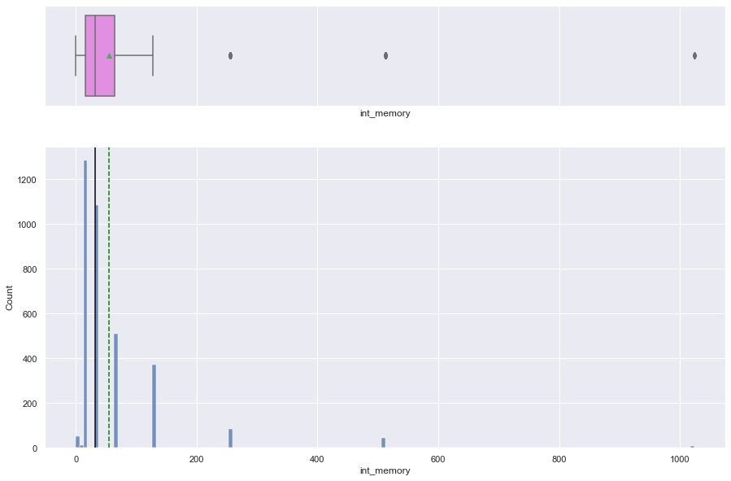

```python
histogram_boxplot(df, "int_memory")  # show histogram and boxplot of internal memory
```

- This is a right skewed distribution. 50% of the phones have internal memory sizes less than the average.
- There is a wide gap between the minimum and maximum values indicating that there are some phones with very high internal memory.

#### DISTRIBUTION OF RAM

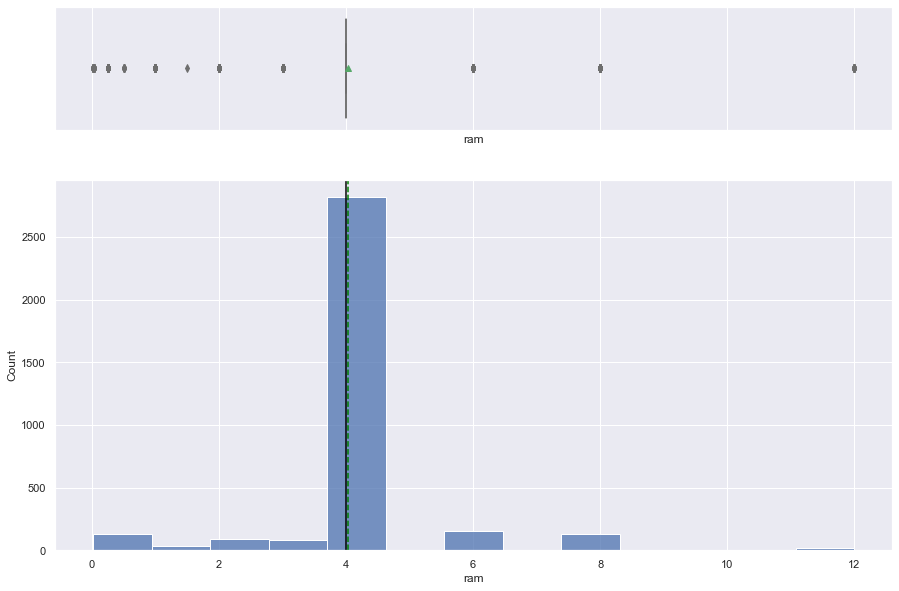

```python
histogram_boxplot(df, "ram")  # show histogram and boxplot of ram
```

- The distribution indicates that majority of the phones have ram size of 4 GB.
- The average ram size and median value are fairly equal.
- The maximum ram size is three times greater than the average ram size.

#### DISTRIBUTION OF WEIGHT

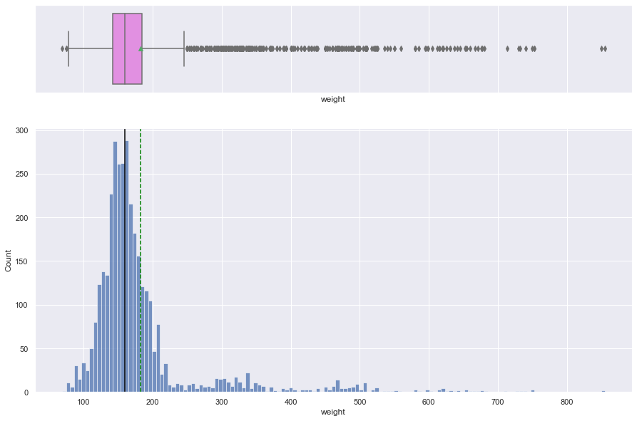

```python
histogram_boxplot(df, "weight")  # show histogram and boxplot of weight
```

- This is a fairly right skewed distribution with many outliers to the right of the upper whisker. 50% of phones have weight less than the average.
- The distribution shows some heavy phones on the market.

#### DISTRIBUTION OF BATTERY

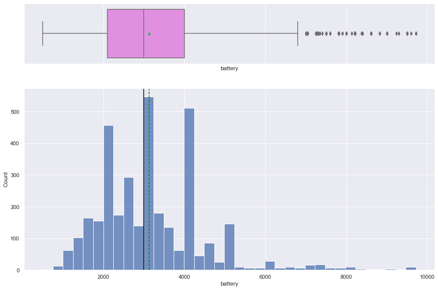

```python
histogram_boxplot(df, "battery")  # show histogram and boxplot of battery
```

- The distribution is fairly right skewed with the presence of outliers to the right of the upper whisker.
- The battery capacity of half of the phones are less than the average.
- The average value is slightly greater than the median value hence the slight skewness.

#### DISTRIBUTION OF DAYS USED

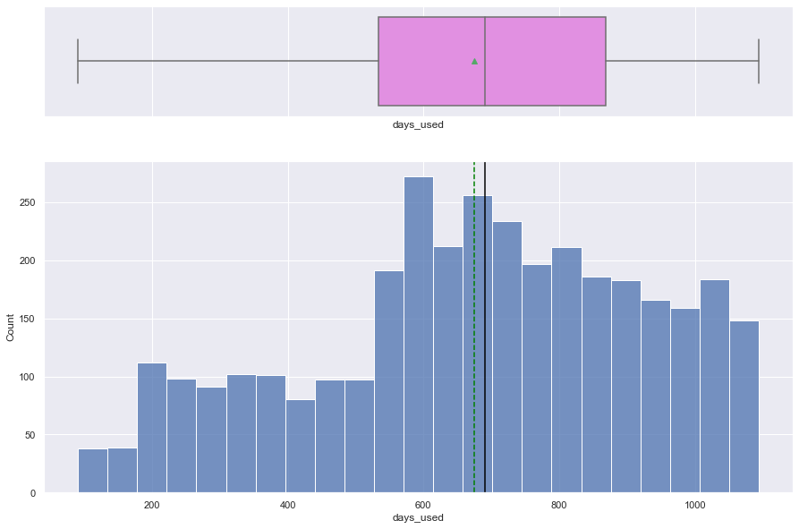

```python
histogram_boxplot(df, "days_used")  # show histogram and boxplot of days used
```

#### DISTRIBUTION OF BRAND NAME

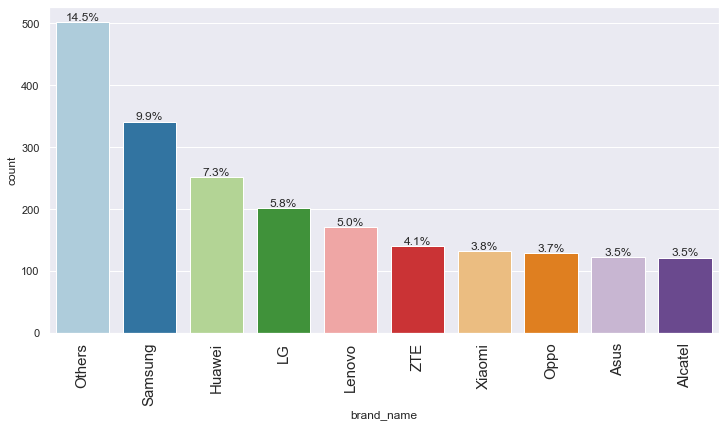

```python
labeled_barplot(df, "brand_name", perc=True, n=10)  # Show bar graph of brand name
```

- The brands in the 'Others' category are the most in the dataset.
- ZEE, Xiaomi, Oppo, Asus, Alcatel represent less than 5% of the brand population.
- Besides others, Samsung, Huawei and LG are the top three in the brand population.

#### DISTRIBUTION OF OS

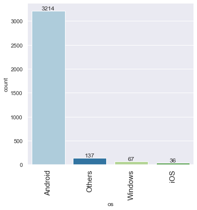

```python
labeled_barplot(df, "os")  # show bar graph of the OS
```

```python
df["os"].value_counts(normalize=True)
```

```
Android    0.930515
Others     0.039664
Windows    0.019398
iOS        0.010423
Name: os, dtype: float64
```

- There are 4 categories in the OS column.
- More than 90% of android phones is represented in the dataset; ios is the least represented.

#### DISTRIBUTION OF 4G

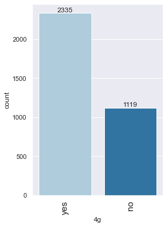

```python
labeled_barplot(df, "4g")  # show bar graph of the 4g
```

- There are more phones that use the 4g technology than those that do not.

#### DISTRIBUTION OF 5G

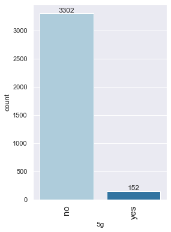

```python
labeled_barplot(df, "5g")  # show bar graph of the 5g
```

- Very few phones are configured for the 5g technology.

#### DISTRIBUTION OF RELEASED YEAR

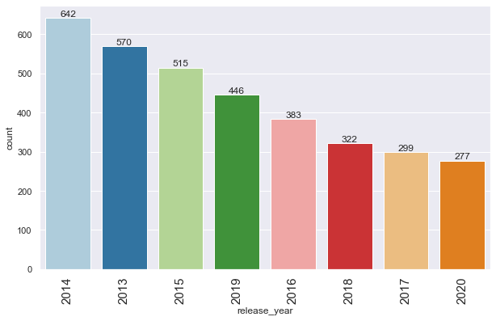

```python
labeled_barplot(df, "release_year")  # show bar graph of the released year
```

- Phones manufactured in 2014 are the most. Phones made in 2020 are the least represented in the dataset.
- Phones made in 2013 and 2015 are second and third respectively to those made in 2014.

#### CORRELATION CHECK

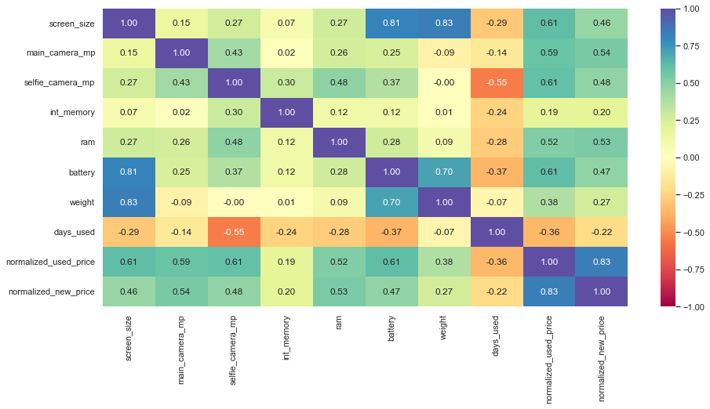

```python
cols_list = df.select_dtypes(include=np.number).columns.tolist()
# dropping release_year as it is a temporal variable
cols_list.remove("release_year")

plt.figure(figsize=(15, 7))  # size configuration of the plot
sns.heatmap(
    df[cols_list].corr(), annot=True, vmin=-1, vmax=1, fmt=".2f", cmap="Spectral"
)  # show heatmap of selected columns
plt.show()  # plot graph
```

#### The amount of RAM is important for the smooth functioning of a device. Let's see how the amount of RAM varies across brands.

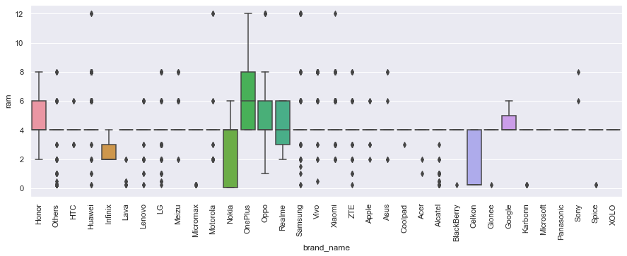

```python
plt.figure(figsize=(15, 5))  # size configuration of the plot
sns.boxplot(data=df, x="brand_name", y="ram")  # create a boxplot of brand name and ram
plt.xticks(rotation=90)  # angle configuration of labels
plt.show()  # show plot
```

- OnePlus has the highest average ram size and also the maximum ram size.
- Most of the brands have an average ram size of 4 GB.

#### People who travel frequently require devices with large batteries to run through the day. But large battery often increases weight, making it feel uncomfortable in the hands. Let's create a new dataframe of only those devices which offer a large battery and analyze.

```python
df_large_battery = df[
    df.battery > 4500
]  # create dataframe of devices with battery capacity greater than 4500 mAh
df_large_battery.shape  # show number of rows and columns of dataframe
print(
    "There are", df_large_battery.shape[0], "devices with large batteries."
)  # print statement of output
```

```
There are 341 devices with large batteries.
```

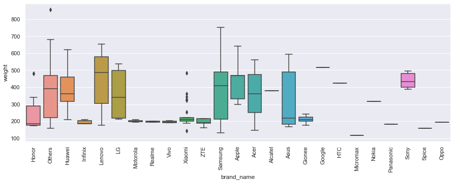

```python
plt.figure(figsize=(15, 5))  # size configuration of plot
sns.boxplot(
    data=df_large_battery, x="brand_name", y="weight"
)  # Create a boxplot for 'brand_name' and 'weight'
plt.xticks(rotation=90)  # angle configuration of labels
plt.show()  # show plot
```

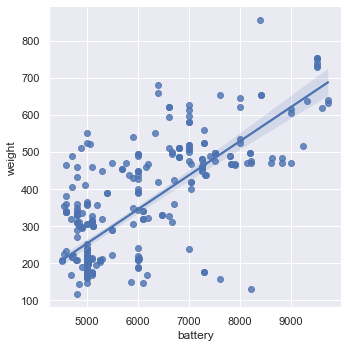

```python
plt.figure(figsize=(15, 5))  # size configuration of plot
sns.lmplot(
    data=df_large_battery, x="battery", y="weight"
)  # create scatterplot with line of fit
```

- Google has the highest mean weight while a phone in the others category has the maximum weight.
- There is a significant positive correlation between the battery and the weight. The weight increases with increasing battery capacity.

#### People who buy phones and tablets primarily for entertainment purposes prefer a large screen as they offer a better viewing experience. Let's create a new dataframe of only those devices which are suitable for such people and analyze.

```python
df_large_screen = df[
    df.screen_size > 6 * 2.54
]  # create dataframe of screen size greater than 6 * 2.54
df_large_screen.shape  # show number of rows and columns in the dataframe
print(
    "There are", df_large_screen.shape[0], "devices with large screens."
)  # print statement of output
```

```
There are 1099 devices with large screens.
```

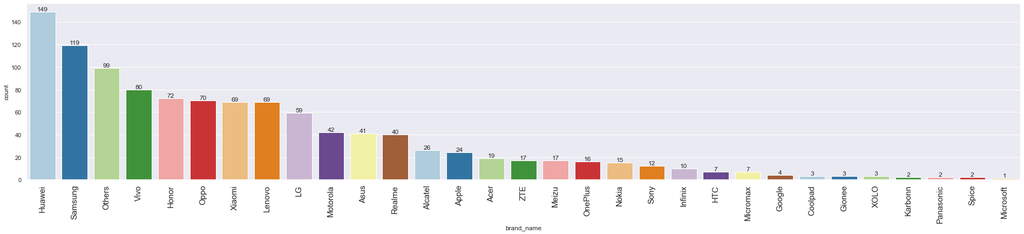

```python
labeled_barplot(df_large_screen, "brand_name")  # create bar graph of brand name
```

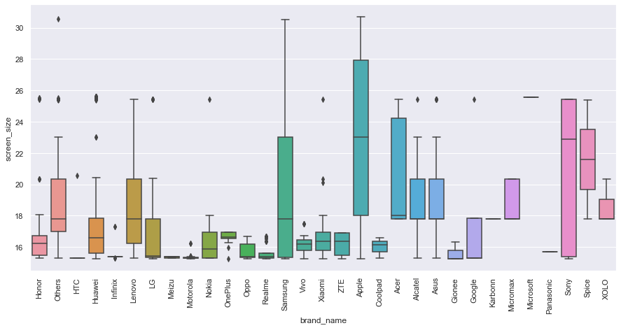

```python
plt.figure(figsize=(15, 7))
# size configuration of the plot
sns.boxplot(data=df_large_screen, x="brand_name", y="screen_size")
# create boxplot of brand name and screen size
plt.xticks(rotation=90)
# angle configuration of labels
plt.show()  # plot and show graph
```

#### Everyone likes a good camera to capture their favorite moments with loved ones. Some customers specifically look for good front cameras to click cool selfies. Let's create a new dataframe of only those devices which are suitable for this customer segment and analyze.

```python
df_selfie_camera = df[
    df.selfie_camera_mp > 8
]  # Create dataframe for phones with selfie camera greater than 8 mp
df_selfie_camera.shape  # show number of rows and columns of the dataframe
print(
    "There are",
    df_selfie_camera.shape[0],
    "devices with selfie camera resolution greater than 8 mp.",
)  # print statement of output
```

```
There are 655 devices with selfie camera resolution greater than 8 mp.
```

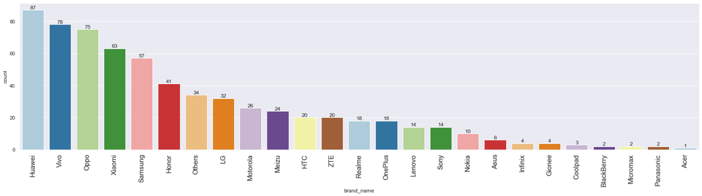

```python
labeled_barplot(
    df_selfie_camera, "brand_name"
)  # create bar graph of high selfie camera brands
```

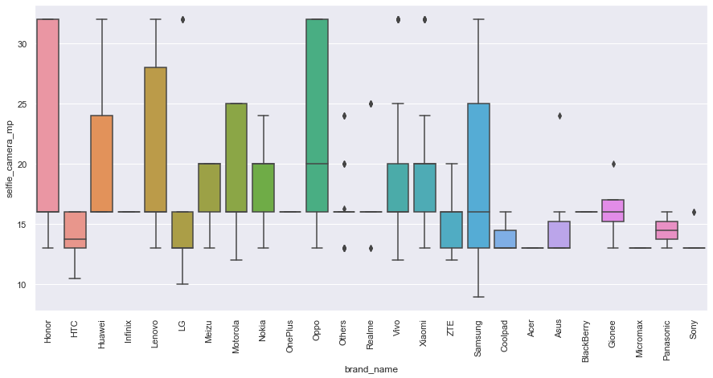

```python
plt.figure(figsize=(15, 7))
# size configuration of the plot
sns.boxplot(data=df_selfie_camera, x="brand_name", y="selfie_camera_mp")
# create boxplot of brand name and screen size
plt.xticks(rotation=90)
# angle configuration of labels
plt.show()  # plot and show graph
```

**Let's do a similar analysis for rear cameras.**

- Rear cameras generally have a better resolution than front cameras, so we set the threshold higher for them at 16MP.

```python
df_main_camera = df[
    df.main_camera_mp > 16
]  # create dataframe of devices with main camera resolution greater than 16 mp
df_main_camera.shape  # show number of rows and columns of the dataframe
print(
    "There are", df_main_camera.shape[0], "devices with high main camera resolution."
)  # print statement of output
```

```
There are 94 devices with high main camera resolution.
```

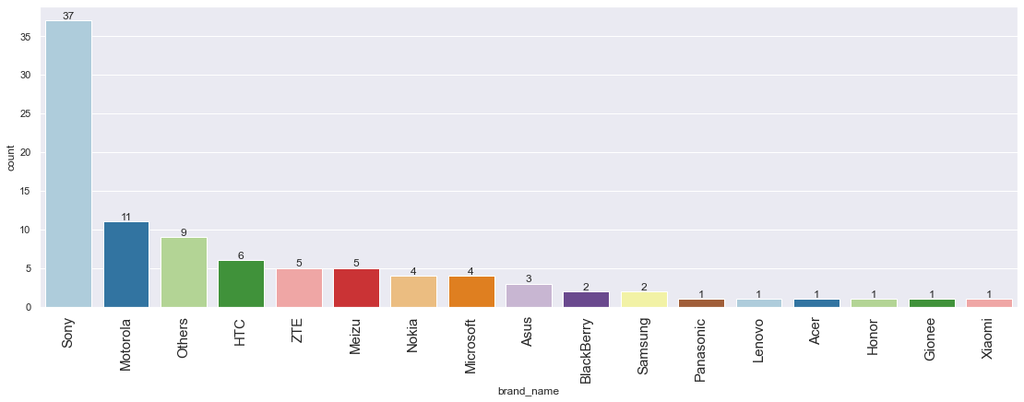

```python
labeled_barplot(
    df_main_camera, "brand_name"
)  # create bar graph of high main camera brands
```

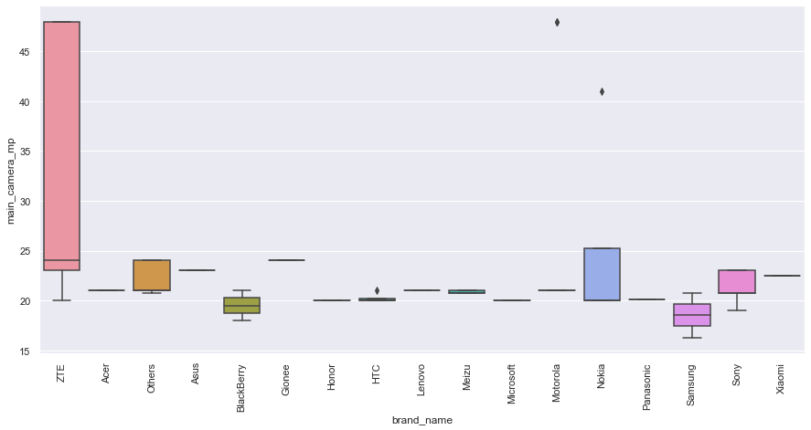

```python
plt.figure(figsize=(15, 7))
# size configuration of the plot
sns.boxplot(data=df_main_camera, x="brand_name", y="main_camera_mp")
# create boxplot of brand name and screen size
plt.xticks(rotation=90)
# angle configuration of labels
plt.show()  # plot and show graph
```

#### Let's see how the price of used devices varies across the years.

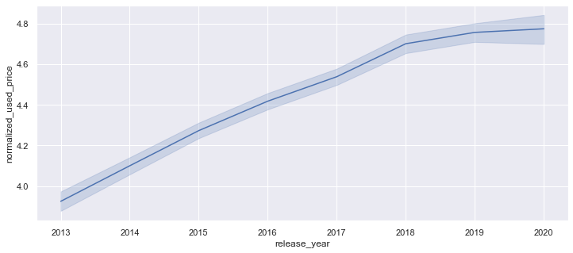

```python
plt.figure(figsize=(12, 5))
# plot size configuration
sns.lineplot(data=df, x="release_year", y="normalized_used_price")
# create a lineplot for release year and used price
plt.show()
```

- The graph shows increasing used price with increasing year. The increment is quite subtle though after 2019.

#### Let's check how the prices vary for used phones and tablets offering 4G and 5G networks.

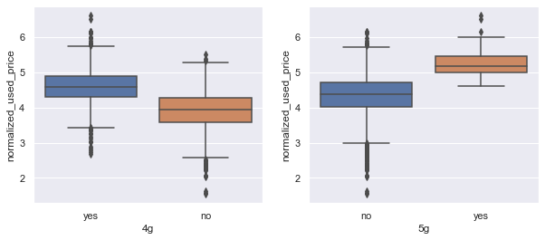

```python
plt.figure(figsize=(10, 4))  # plot size configuration

plt.subplot(121)  # create grid of boxplot
sns.boxplot(
    data=df, x="4g", y="normalized_used_price"
)  # create a boxplot for 4g and used price

plt.subplot(122)  # create grid of boxplot
sns.boxplot(
    data=df, x="5g", y="normalized_used_price"
)  # create a boxplot of 5g and normalized used price

plt.show()
# plot graph
```

##### 4G

- The average price of phones with 4g capability is greater than those without this configuration.
- Some phones are that use 4g technology are significantly more expensive than those that dont as seen in the presence of outliers. ##### 5G
  - The mean price of phones that can use 5g technology is greater than those that dont.
  - There are some relatively exorbitant phones in this category.

  ##### 4G & 5G
  - The average price of phones that use the 5g technology is greater than those that use 4g. However, the maximum cost of both categories are fairly equal.

## Data Preprocessing

- Missing value treatment
- Feature engineering (if needed)
- Outlier detection and treatment (if needed)
- Preparing data for modeling
- Any other preprocessing steps (if needed)

#### MISSING VALUE TREATMENT

```python
df1 = df.copy()  # create a copy of the data
```

```python
df1.isnull().sum()  # checking for missing values
```

```
brand_name                 0
os                         0
screen_size                0
4g                         0
5g                         0
main_camera_mp           179
selfie_camera_mp           2
int_memory                 4
ram                        4
battery                    6
weight                     7
release_year               0
days_used                  0
normalized_used_price      0
normalized_new_price       0
dtype: int64
```

- main_camera_mp, selfie_camera_mp, int_memory, ram, battery & weight are the columns with missing values.

```python
cols_impute = [
    "main_camera_mp",
    "selfie_camera_mp",
    "int_memory",
    "ram",
    "battery",
    "weight",
]

for col in cols_impute:
    df1[col] = df1[col].fillna(
        value=df1.groupby(["release_year", "brand_name"])[col].transform("median")
    )  # impute missing values in cols_impute with median by grouping the data on release year and brand name

df1.isnull().sum()  # check missing values after imputing the above columns
```

```
brand_name                 0
os                         0
screen_size                0
4g                         0
5g                         0
main_camera_mp           179
selfie_camera_mp           2
int_memory                 0
ram                        0
battery                    6
weight                     7
release_year               0
days_used                  0
normalized_used_price      0
normalized_new_price       0
dtype: int64
```

- int_memory and ram have been treated for missing values.

#### TREATMENT FOR MAIN CAMERA MP

```python
df1["main_camera_mp"] = df1["main_camera_mp"].fillna(
    df1["main_camera_mp"].median()
)  # impute the data with median

# checking for missing values
df1.isnull().sum()  ## Complete the code to check missing values after imputing the above columns
```

```
brand_name               0
os                       0
screen_size              0
4g                       0
5g                       0
main_camera_mp           0
selfie_camera_mp         2
int_memory               0
ram                      0
battery                  6
weight                   7
release_year             0
days_used                0
normalized_used_price    0
normalized_new_price     0
dtype: int64
```

#### TREATMENT FOR SELFIE CAMERA MP

```python
df1["selfie_camera_mp"] = df1["selfie_camera_mp"].fillna(
    df1["selfie_camera_mp"].median()
)  # impute the data with median

# checking for missing values
df1.isnull().sum()
```

```
brand_name               0
os                       0
screen_size              0
4g                       0
5g                       0
main_camera_mp           0
selfie_camera_mp         0
int_memory               0
ram                      0
battery                  6
weight                   7
release_year             0
days_used                0
normalized_used_price    0
normalized_new_price     0
dtype: int64
```

#### TREATMENT FOR BATTERY

```python
df1["battery"] = df1["battery"].fillna(
    df1["battery"].median()
)  # impute the data with median

# checking for missing values
df1.isnull().sum()
```

```
brand_name               0
os                       0
screen_size              0
4g                       0
5g                       0
main_camera_mp           0
selfie_camera_mp         0
int_memory               0
ram                      0
battery                  0
weight                   7
release_year             0
days_used                0
normalized_used_price    0
normalized_new_price     0
dtype: int64
```

#### TREATMENT FOR WEIGHT

```python
df1["weight"] = df1["weight"].fillna(
    df1["weight"].median()
)  # impute the data with median

# checking for missing values
df1.isnull().sum()
```

```
brand_name               0
os                       0
screen_size              0
4g                       0
5g                       0
main_camera_mp           0
selfie_camera_mp         0
int_memory               0
ram                      0
battery                  0
weight                   0
release_year             0
days_used                0
normalized_used_price    0
normalized_new_price     0
dtype: int64
```

All missing values have been treated.

#### Feature Engineering

```python
df1["years_since_release"] = (
    2021 - df1["release_year"]
)  # create new column called years_since_release from release_year column
df1.drop("release_year", axis=1, inplace=True)  # drop release_year column
df1["years_since_release"].describe()  # show statistical summary
```

```
count    3454.000000
mean        5.034742
std         2.298455
min         1.000000
25%         3.000000
50%         5.500000
75%         7.000000
max         8.000000
Name: years_since_release, dtype: float64
```

- The average age of the phones is about five (5) years.
- The oldest phone in the set is eight (8) years old.
- 50% of phones are about 5.5 years old.
- The standard deviation indicates that age of the phones is not widely spread.

```python
df1.head()  # view first five rows of the dataframe
```

|  | brand_name | os | screen_size | 4g | 5g | main_camera_mp | selfie_camera_mp | int_memory | ram | battery | weight | days_used | normalized_used_price | normalized_new_price | years_since_release |
| --- | --- | --- | --- | --- | --- | --- | --- | --- | --- | --- | --- | --- | --- | --- | --- |
| 0 | Honor | Android | 14.50 | yes | no | 13.0 | 5.0 | 64.0 | 3.0 | 3020.0 | 146.0 | 127 | 4.307572 | 4.715100 | 1 |
| 1 | Honor | Android | 17.30 | yes | yes | 13.0 | 16.0 | 128.0 | 8.0 | 4300.0 | 213.0 | 325 | 5.162097 | 5.519018 | 1 |
| 2 | Honor | Android | 16.69 | yes | yes | 13.0 | 8.0 | 128.0 | 8.0 | 4200.0 | 213.0 | 162 | 5.111084 | 5.884631 | 1 |
| 3 | Honor | Android | 25.50 | yes | yes | 13.0 | 8.0 | 64.0 | 6.0 | 7250.0 | 480.0 | 345 | 5.135387 | 5.630961 | 1 |
| 4 | Honor | Android | 15.32 | yes | no | 13.0 | 8.0 | 64.0 | 3.0 | 5000.0 | 185.0 | 293 | 4.389995 | 4.947837 | 1 |

#### OUTLIER DETECTION

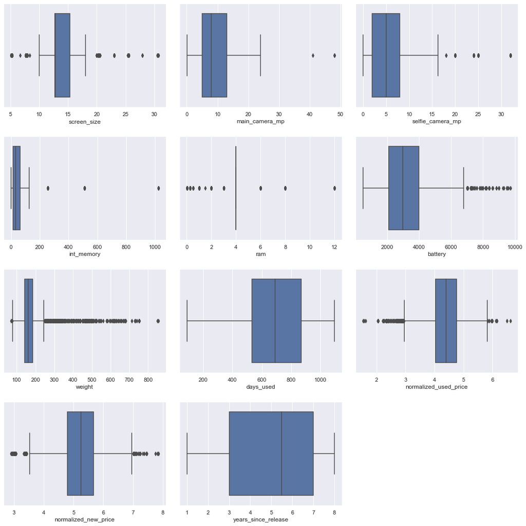

```python
# outlier detection using boxplot
num_cols = df1.select_dtypes(include=np.number).columns.tolist()

plt.figure(figsize=(15, 15))

for i, variable in enumerate(num_cols):
    plt.subplot(4, 3, i + 1)
    sns.boxplot(data=df1, x=variable)
    plt.tight_layout(pad=2)

plt.show()
```

- There are outliers in the distributions except for days_used and years_since_release. However, this will not be treated as they represent part of the information. Treatment could result in loss of it.